# Verkefni 2

Brynjar Mar (bmb23), Kári Einarsson (kae44) og Indriði Már Indriðason (imi2)

2024-04-12

```r
library(tidyverse)
library(ggplot2)
library(scales)
library(knitr)
library(dplyr)
library(tidyr)
```

# Hluti 1 - Gagnamöndl (10 %)

## a)

Lesið gagnasafnið inn í R/RStudio með skipuninni hér að neðan og geymið í hlut sem ber upphafsstafi þeirra sem verkefnið vinna (ef Gréta Halldórsdóttir og Sigurður Karl Jónsson eru að vinna saman skulu þau nefna hlutinn gs).

nafn_a_hlut <- read_csv2(“https://ahj.hi.is/kaupskra.csv”, locale = locale(encoding = “ISO8859-1”))

þar sem þið skiptið nafn_a_hlut út fyrir upphafsstafina (þó skal ekki nota íslenska stafi).

```r
bik <- read_csv2("https://ahj.hi.is/kaupskra.csv", locale = locale(encoding = "ISO8859-1"))
```

medaltal taknad med $\mu$

## b)

Notið filter() skipunina til að velja fullbúnar eignir (sjá fullbuid breytuna) sem eru “Fjolbyli” og “Serbyli” og byggja á samningum sem eru er nothæfir. Yfirskrifið stóra gagnaramman í a) lið með þessum eignum.

```r
tegund_inni <- c("Serbyli", "Fjolbyli")
bik <- filter(bik, fullbuid==1, tegund%in%tegund_inni, onothaefur_samningur==0)
```

## c)

Búið til nýja breytu í gagnarammanum ykkar sem inniheldur fermetraverð eignanna, nefnið breytuna fermetraverd.

```r
bik <- mutate(bik, fermetraverd=kaupverd/einflm)
```

## d)

Búið til nýja breytu í gagnarammanum ykkar sem inniheldur árið sem eignin var seld, nefnið breytuna ar (t.d. með að nota year() fallið í lubridate pakkanum).

```r
bik <- mutate(bik, ar=year(utgdag))
```

## e)

Veljið ykkur þrjú póstnúmer til að vinna með. Það þurfa að vera a.m.k. 200 sérbýli í hverju póstúmeri fyrir sig. Yfirskrifið gagnaramman í b) lið með eignum úr þessum þremur póstnúmerum. Þið skulið nota þennan gagnaramma í verkefninu.

```r
pnr <- c(107, 105, 210)
bik <- filter(bik, postnr%in%pnr)
```

## f)

Kannið gerð breytanna í gagnarammanum ykkar og breytið ef þarf.

```r
bik <- mutate(bik, emnr = factor(emnr))
bik <- mutate(bik, postnr = factor(postnr))
```

## g)

Hugsum okkur nú að eignirnar í gagnarammanum ykkar sé þýðið ykkar. Nú ætlum við að taka úrtak úr þýðinu, 200 eignir úr hverju hverfi. Það má gera á eftirfarandi hátt:

```r
set.seed(39)
bik %>%
group_by(postnr) %>%
sample_n(size = 200) -> urtak
```

# Hluti 2 - Töflur (25 %)

## h) Búið til töflu sem sýnir fjölda eigna í hverfunum þremur eftir gerð eigna (sérbýli eða fjölbýli).

```r
urtak %>%
  count(postnr, tegund) %>%
  spread(key = tegund, value = n)
```

```
## # A tibble: 3 × 3
## # Groups:   postnr [3]
##   postnr Fjolbyli Serbyli
##   <fct>     <int>   <int>
## 1 105         197       3
## 2 107         186      14
## 3 210         133      67
```

## i) Búið til töflu sem sýnir hlutfall sérbýla og fjölbýla í hverfunum þremur. Það á s.s. að vera hægt að lesa hvert hlutfall sérbýla og fjölbýla er í hverju hverfi fyrir sig.

```r
# Finna fjolda af hverri tegund i hverju  postsnr
fjoldi <- table(urtak$postnr, urtak$tegund)

# Hlutfall fjolda
hlutfall <- prop.table(fjoldi, margin = 1)

#  Yfir  i %
prosent <- round(hlutfall * 100, digits = 2)

prosent
```

```
##
##       Fjolbyli Serbyli
##   105     98.5     1.5
##   107     93.0     7.0
##   210     66.5    33.5
```

## j) Kannið með viðeigandi tilgátuprófi hvort hlutfall fjölbýla sé misjafnt í hverfunum þremur. Sýnið úttakið úr prófinu. Eru forsendur til að nota prófið uppfylltar? Setjið tilgáturnar fram, tilgreinið gildið á prófstærðinni, p-gildið og hvaða ályktun þið dragið.

```r
chi_test <- chisq.test(fjoldi)
chi_test
```

```
##
##  Pearson's Chi-squared test
##
## data:  fjoldi
## X-squared = 97.259, df = 2, p-value < 2.2e-16
```

# Hluti 3 - Tilgátuprof (25 %)

## k) Kannið með viðeigandi tilgátuprófi hvort munur sé á meðalfermetraverði fasteigna eftir því hvort þær séu sérbýli eða fjölbýli. Setjið tilgáturnar fram, tilgreinið gildið á prófstærðinni, p-gildið og hvaða ályktun þið dragið.

```r
# Búum til tvö úrtök, eitt fyrir sérbýli og annað fyrir fjölbýli
serbýli <- filter(urtak, tegund == "Serbyli")$fermetraverd
fjölbýli <- filter(urtak, tegund == "Fjolbyli")$fermetraverd

# Framkvæmum t-prófið
t_test_result <- t.test(serbýli, fjölbýli, alternative = "two.sided", var.equal = TRUE)

# Prentum út niðurstöðurnar
print(t_test_result)
```

```
##
##  Two Sample t-test
##
## data:  serbýli and fjölbýli
## t = -2.8352, df = 598, p-value = 0.004734
## alternative hypothesis: true difference in means is not equal to 0
## 95 percent confidence interval:
##  -85.58636 -15.53835
## sample estimates:
## mean of x mean of y
##  367.1402  417.7026
```

### Tilgáturnar

- *Núlltilgáta (H0):* Það er enginn munur á meðalfermetraverði milli sérbýla og fjölbýla. $μ_{sérbýli} = μ_{fjölbýli}$
- *Gagntilgáta (H1):* Það er munur á meðalfermetraverði milli sérbýla og fjölbýla. $μ_{sérbýli} ≠ μ_{fjölbýli}$

### Ályktun

Niðurstöður prófsins leiða í ljós að við getum höfnun núlltilgátunni og samþykkt gagntilgátuna að það sé marktækur munur á meðalfermetraverði milli sérbýla og fjölbýla. Meðalfermetraverð sérbýlis er marktækt lægra en meðalfermetraverð fjölbýlis, sem sýnt er með neikvæðu t-gildinu og því að p-gildið er undir 0.05. Þetta þýðir að sérbýli eru að meðaltali ódýrari en fjölbýli miðað við fermetraverð.

## l) Búið til nýja breytu, staerd200, sem gefur til kynna hvort eignir séu stærri eða minni en 200 fermetrar (það skiptir ekki máli í hvorum flokknum 200 fermetra eignir lenda). Kallið flokkinn með stærri eignunum Stærri og minni eignunum Minni. Ábending: notið ifelse() til að búa til breytuna.

```r
urtak$staerd200 <- ifelse(urtak$einflm >= 200, "Stærri", "Minni")

# Skoðum fyrstu færslurnar til að sjá breytingarnar
head(urtak$staerd200)
```

```
## [1] "Stærri" "Minni"  "Minni"  "Minni"  "Minni"  "Minni"
```

## m) Kannið með viðeigandi tilgátuprófi hvort munur sé á meðalfermetraverði fasteigna eftir því hvort þær séu stærri eða minni en 200 fermetrar. Setjið tilgáturnar fram, tilgreinið gildið á prófstærðinni, p-gildið og hvaða ályktun þið dragið.

```r
# Gerum ráð fyrir að bik sé gagnarammi sem inniheldur fermetraverð í dálkinum 'verd'
# og flokkun eftir stærð í 'staerd200' dálkinum

# Skiptum gögnunum í tvo hópa
staerri <- urtak$fermetraverd[urtak$staerd200 == "Stærri"]
minni <- urtak$fermetraverd[urtak$staerd200 == "Minni"]

# Framkvæmum t-próf fyrir óháð sýni
t_test_result2 <- t.test(staerri, minni)

# Prentum út niðurstöðurnar
print(t_test_result2)
```

```
##
##  Welch Two Sample t-test
##
## data:  staerri and minni
## t = -3.4824, df = 79.45, p-value = 0.000811
## alternative hypothesis: true difference in means is not equal to 0
## 95 percent confidence interval:
##  -92.51255 -25.22317
## sample estimates:
## mean of x mean of y
##  357.4466  416.3144
```

### Tilgáturnar

- *Núlltilgáta (H0):* Það er enginn munur á meðalfermetraverði milli fasteigna sem eru stærri en 200 fermetrar og þeirra sem eru minni en 200 fermetrar.
  $$μ_{stærri} =
  μ_{minni}$$
- *Gagntilgáta (H1):* Það er munur á meðalfermetraverði milli fasteigna sem eru stærri en 200 fermetrar og þeirra sem eru minni en 200 fermetrar.
  $$μ_{stærri} ≠
  μ_{minni}$$

### Ályktun

Niðurstöður t-prófsins leiða í ljós að það er marktækur munur er á meðalfermetraverði milli fasteigna sem eru stærri eða minni en 200 fermetrar. Meðaltalið af fermetraverði stærri eigna er lægra en meðaltalið af fermetraverði minni eigna. T-gildið og p-gildið gefa til kynna að þessi munur sé tölfræðilega marktækur. Því getum við ályktað að stærð eigna hafi áhrif á fermetraverð, þar sem minni eignir virðast hafa hærra meðalfermetraverð í þessu úrtaki.

# Hluti 4 (30%)

## n) Teiknið viðeigandi mynd af breytunum fermetraverd og postnr

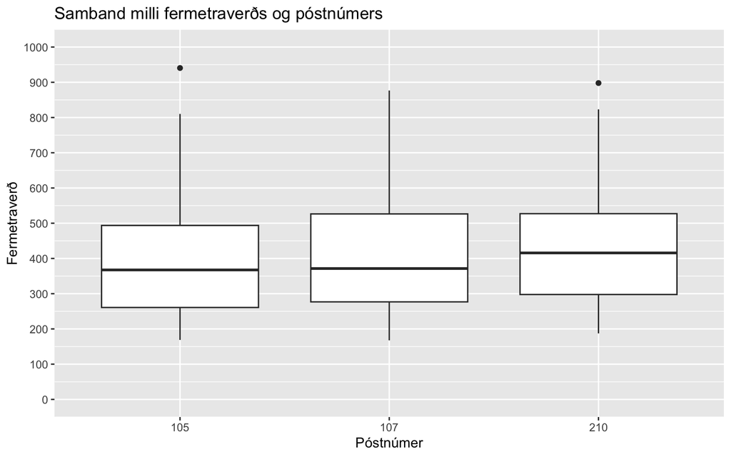

```r
ggplot(urtak, aes(x=postnr, y=fermetraverd)) +
  geom_boxplot() +
  scale_y_continuous(breaks=seq(0, 1000, by=100), limits=c(0, 1000)) +
  labs(title="Samband milli fermetraverðs og póstnúmers",
       x="Póstnúmer",
       y="Fermetraverð")
```

## o)

Kannið með viðeigandi tilgátuprófi hvort munur sé á meðalfermetraverði fasteigna í hverfunum þremur. Sýnið úttakið úr prófinu. Setjið tilgáturnar fram, tilgreinið gildið á prófstærðinni, p-gildið og hvaða ályktun þið dragið. Segði nokkur orð um hvort forsendur tilgátuprófsins séu uppfylltar. Þið þurfið ekki að prófa það með tilgátuprófi, nóg er að notast við myndrit (t.d. myndina í lið n).

```r
fervikagreining <- aov(fermetraverd ~ postnr, data = urtak)

summary_fervik  <- summary(fervikagreining)
f_value <- summary_fervik[[1]]["postnr", "F value"]
p_value <- summary_fervik[[1]]["postnr", "Pr(>F)"]
summary_fervik
```

```
##              Df   Sum Sq Mean Sq F value Pr(>F)
## postnr        2   114325   57163   2.471 0.0853 .
## Residuals   597 13809344   23131
## ---
## Signif. codes:  0 '***' 0.001 '**' 0.01 '*' 0.05 '.' 0.1 ' ' 1
```

### Núlltilgáta

Það er enginn munur á meðal fermetraverði í hverfunum.

### Gagntilgáta

Allavega eitt hverfi hefur öðruvísi meðal fermetraverð en hin hverfin.

### Prófstærð og p-gildi

Prófstærðin er F-gildið og það er 2.4712314 og p-gildið er 0.0853446

### Ályktun

Þar sem p-gildið er ekki minna en 0.05 er ekki hægt að hafna núlltilgátunni. Þetta þýðir að það er ekki hægt að segja að það sé umtalsverður munur á meðal fermetraverði milli hverfa. Miðað við boxplot að ofan þá sést að það eru einhverjir útlagar og einnig er p-gildið nálægt 0.05 sem þýðir að það er einhver munur en ekki alvveg nógu mikill. Það væri því gott að taka stærra úttak því það gæti gefið niðurstöður sem myndu hafna núlltilgátunni.